# Lista 2

Aluno: Gustavo Luiz Bispo dos Santos - 117210400

Aluno: Diego Amancio Pereira - 116210716

Aluno: Gilmar Gonzaga da Silva - 119211123

Aluno: Anderson Kleber Dantas - 117110537

2022-08-26

1. Apresente/Descreva um problema em que seja necessário o planejamento e o desenvolvimento de uma pesquisa(estudo) estatística(o) para que o mesmo seja resolvido.

   Com a chegada da pandemia foi necessário a adoção de uma biblioteca virtual para os estudantes da UFCG, mas é necessário avaliar se os mesmos mudaram seus hábitos de estudo, ou seja, começaram a adotar o estudo usando ebooks em detrimento do livro físico.
2. A partir do problema descrito acima:
   1. Diga qual é a população associada ao problema e o tipo.  
      População: Estudantes de ciência da computação da UFCG.  
      Tipo: População infinita.
   2. Apresente os objetivos geral e específicos do estudo(pesquisa) estatístico(a).

      Tentar descobrir se com o uso de ebooks, os discentes do curso de Ciência da Computação da Universidade Federal de Campina Grande preferem usar ebooks para estudar.
   3. Diga quais variáveis e quais os seus tipos (categórica ou quantitativa) podem ser de interesse na pesquisa.

      Satisfação de uso de (ebooks), quantitativa;  
      Frequência de uso (ebooks), quantitativa;  
      Disponibilidade (ebooks), quantitativa.
   4. A pesquisa requer a coleta de uma amostra? Por que?

      Sim, pois tem mais de 500 alunos no curso de ciencia da computação, (graduação e pós), por isso decidimos que a amostra seria uma parcela dos graduandos de ciência da computação da UFCG, que são a parte da população mais afetada pelo problema.
   5. Na sua pesquisa o que pode ser apresentado como exemplo de parâmetro, estatística e estimativa?

      VA: Satisfação de uso de E-books.  
      Parâmetro: Número de elementos com grande satisfação.  
      Estimativa: Seria o valor aproximado desse parâmetro.
3. Apresente ou colete uma base de dados necessária para a resolução de um problema (pode ser o mesmo do item 1) que requer uma análise estatística descritiva e inferencial.
   1. Descreva o problema, população, amostra, tipo de amostragem, objetivos geral e específicos, variáveis e tipos correspondentes (qualitativa ou quantitativa), além de dizer quais são os parâmetros que mais interessam analisar.

      O problema é o mesmo das questões 1 e 2.
   2. Anexe; separadamente; a base de dados em excel ou csv ou disponibilize o link de acesso á base.

      [Link de acesso](https://docs.google.com/spreadsheets/d/1jRjWfcmxZGpSc55HqNKGVJooyXhJxOIiTrBUHxU25I0/edit?usp=sharing)
   3. Desenvolva análise exploratória e descritiva dos dados sempre buscando responder aos objetivos e ou hipóteses da pesquisa / problema, com insigths de interesse prático.

      Inicialmente organizamos os dados de interesse e fizemos um resumo em forma de gráficos de frequência:

```
## # A tibble: 42 × 6
##    ebookStudyAvaliable isSatisfactoryUseEbook isEbookB…¹ bibli…² easyA…³ ebook…⁴
##                  <dbl>                  <dbl>      <dbl>   <dbl>   <dbl> <chr>
##  1                   3                      4          4       4       4 1 a 3 …
##  2                   3                      1          4       3       3 Rarame…
##  3                   2                      3          5       4       4 Rarame…
##  4                   5                      5          4       4       4 1 a 3 …
##  5                   3                      4          5       4       4 1 a 3 …
##  6                   1                      5          5       2       2 Rarame…
##  7                   4                      5          5       3       3 1 a 3 …
##  8                   4                      1          5       2       2 Rarame…
##  9                   2                      1          5       3       3 Rarame…
## 10                   5                      5          5       3       3 Mais d…
## # … with 32 more rows, and abbreviated variable names
## #   ¹isEbookBetterPhysicalBook, ²bibliographCourseAvaliable,
## #   ³easyAcessUfcgEbooks, ⁴ebookReadFrequency
```

valor 1 = discordo totalmente.

valor 2 = discordo.

valor 3 = neutro.

valor 4 = concordo.

valor 5 = concordo totalmente.

# Grafico frequência de leitura de ebook/disponivel online na biblioteca da UFCG

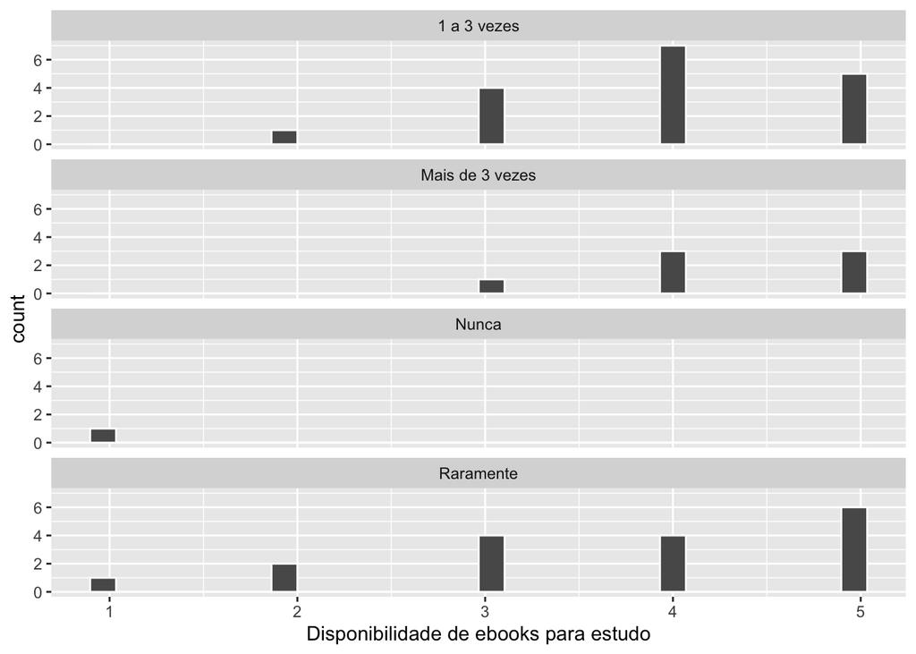

```r
ggplot(data = teste2, mapping = aes(x = ebookStudyAvaliable)) +
  geom_histogram(color = "white") +
  facet_wrap(~ ebookReadFrequency, ncol = 1) +
  labs(x="Disponibilidade de ebooks para estudo")
```

Com base no gráfico acima, foi observado que o fato de o livro ser usado em disciplina e estar disponível na biblioteca virtual parece implicar em maior procura e consequentemente, maior utilização de livros em formato digital (ebook). Entao foi aplicado um teste de correlação para verificar esta hipótese:

# Correlação de “Os livros que preciso durante o meu estudo, marjoritariamente estão disponíveis em e-book” com “frequencia de leitura semanal dos ebooks”.

```r
ebookReadFrequency = teste2$ebookReadFrequency

ebookFreqAux = c()

for(i in 1:length(ebookReadFrequency)){
  value <- 2
  indexFreq <- ebookReadFrequency[i]

  if(indexFreq == "Nunca"){
    value <- 1
  }  else if(indexFreq == "Raramente"){
    value <- 3
  }else if(indexFreq == "1 a 3 vezes"){
    value <- 4
  }else if(indexFreq  == "Mais de 3 vezes"){
     value <- 5
  }
  ebookFreqAux <- c(ebookFreqAux, value)
}
cor.test(ebookFreqAux  ,teste2$ebookStudyAvaliable  , method = "spearman", exact=FALSE)
```

```
##
##  Spearman's rank correlation rho
##
## data:  ebookFreqAux and teste2$ebookStudyAvaliable
## S = 9698.4, p-value = 0.1733
## alternative hypothesis: true rho is not equal to 0
## sample estimates:
##       rho
## 0.2141299
```

Conclusão: A correlação não é significativa, pois o p-value não é menor que 0,05.